# Homework 2

#### 2. Apply the QTL analysis on the “listeria” sample data set in r/qtl.

1. Apply the single marker analysis (Sax, 1923) to all markers and summarize the markers which have LOD score > 3.

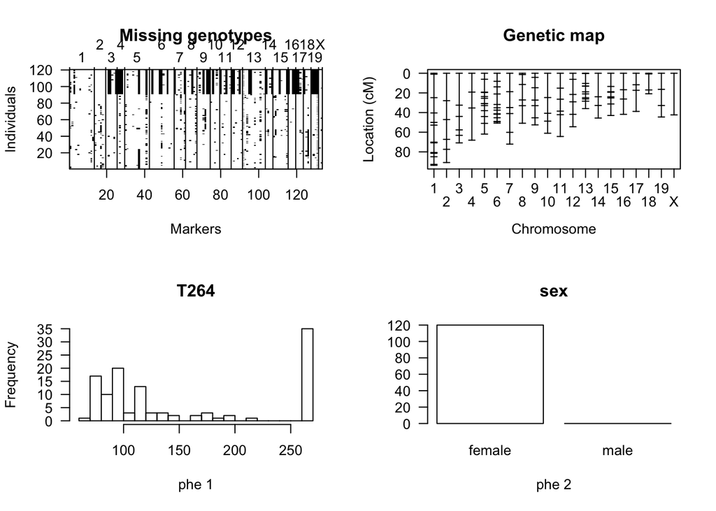

```r
# install.packages("qtl") # don't need to re-download it i
library(qtl)
?listeria # check the details of the dataset
data(listeria) # sample dataset: Susceptibility to Listeria monocytogenes infection in the mouse, 120 F2 females, 133 markers(2 on the X chromosome), phenotype = survival time (in hours) following infection

# data summary
plot(listeria)
```

```r
listeria$pheno #phenotype long table
```

```
##        T264    sex
## 1   118.317 female
## 2   264.000 female
## 3   194.917 female
## 4   264.000 female
## 5   145.417 female
## 6   177.233 female
## 7   264.000 female
## 8    76.667 female
## 9    90.750 female
## 10   76.167 female
## 11  104.083 female
## 12  194.500 female
## 13   75.917 female
## 14   75.833 female
```

[output cut: 106 more lines]

```r
geno.table(listeria) #genotype long table
```

```
##         chr missing CC CB BB not.BB not.CC      P.value
## D10M44    1      19 29 46 26      0      0 0.6125657411
## D1M3      1       3 26 60 31      0      0 0.7771384555
## D1M75     1      24 15 52 29      0      0 0.0930144892
## D1M215    1       3 22 63 32      0      0 0.3009368909
## D1M309    1       2 31 52 35      0      0 0.3805637036
## D1M218    1       2 30 52 36      0      0 0.3212315037
## D1M451    1       0 29 57 34      0      0 0.6988400895
## D1M504    1       0 31 55 34      0      0 0.6116062006
## D1M113    1       0 30 57 33      0      0 0.7985162188
## D1M355    1       0 30 57 33      0      0 0.7985162188
## D1M291    1       5 26 59 30      0      0 0.8367241192
## D1M209    1      12 26 57 25      0      0 0.8386801055
## D1M155    1       5 26 59 30      0      0 0.8367241192
## D2M365    2       7 24 61 28      0      0 0.6065306597
## D2M37     2       1 29 60 30      0      0 0.9874740688
## D2M396    2       3 27 62 28      0      0 0.8041666799
## D2M493    2      30 24 44 22      0      0 0.9355069850
## D2M226    2       9 33 54 24      0      0 0.4628879466
## D2M148    2       0 34 62 24      0      0 0.4065696597
## D3M265    3       0 33 66 21      0      0 0.1652988882
## D3M51     3      33 26 46 15      0      0 0.2155671626
## D3M106    3      30 28 45 17      0      0 0.2606844924
## D3M257    3       2 33 69 16      0      0 0.0158582121
## D3M147    3       5 29 69 17      0      0 0.0286622626
## D3M19     3      30 23 50 17      0      0 0.3845984194
## D4M2      4      30 18 49 23      0      0 0.5308194506
## D4M178    4      44 12 46 18      0      0 0.1155681665
## D4M187    4      30 13 48 29      0      0 0.0476227617
## D4M251    4       0 22 62 36      0      0 0.1826835241
## D5M148    5      11 27 47 35      0      0 0.1980439991
## D5M232    5       7 26 53 34      0      0 0.4569479266
## D5M257    5       0 32 55 33      0      0 0.6537697851
## D5M83     5       0 31 56 33      0      0 0.7408182207
## D5M307    5       4 32 53 31      0      0 0.6442585409
## D5M357    5       0 31 58 31      0      0 0.9355069850
## D5M205    5       4 27 56 33      0      0 0.6843332004
## D5M398    5      57 15 30 18      0      0 0.8071177470
## D5M91     5       0 27 59 34      0      0 0.6537697851
## D5M338    5       0 27 61 32      0      0 0.7985162188
```

[output cut: 79 more lines]

```
## D16M86   16      30 24 45 21      0      0 0.9048374180
## D17M260  17      30 22 46 22      0      0 0.9780228725
## D17M66   17      30 19 47 24      0      0 0.6930406201
## D17M88   17      15 22 57 26      0      0 0.5838593069
## D17M129  17       3 27 58 32      0      0 0.8041666799
## D18M94   18      30 30 40 20      0      0 0.1888756028
## D18M58   18       7 32 54 27      0      0 0.7175889212
## D18M106  18      40 23 40 17      0      0 0.6376281516
## D18M186  18       0 35 53 32      0      0 0.4099718965
## D19M68   19      30 23 45 22      0      0 0.9889503893
## D19M117  19      34 26 43 17      0      0 0.3899017615
## D19M65   19      32 27 43 18      0      0 0.3893869039
## D19M10   19      31 26  0  0      0     63 0.3586266707
## DXM186    X       1 69 50  0      0      0 0.0815562004
## DXM64     X       5 52 63  0      0      0 0.3050069459
```

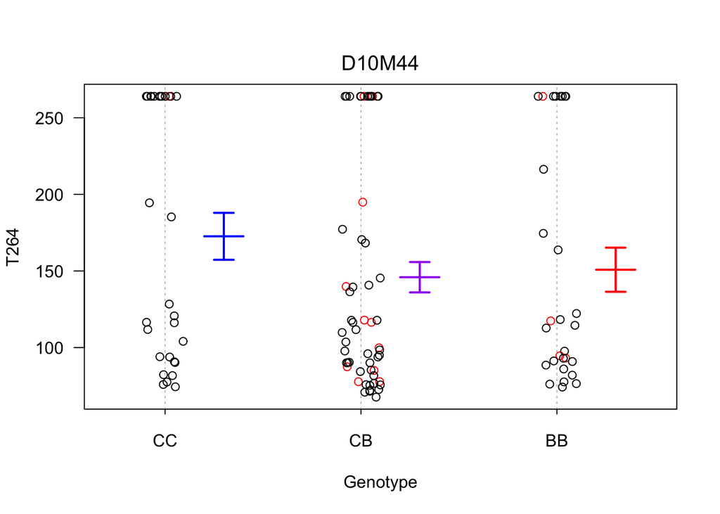

```r
plotPXG(listeria,"D10M44") # plot one marker as an example
```

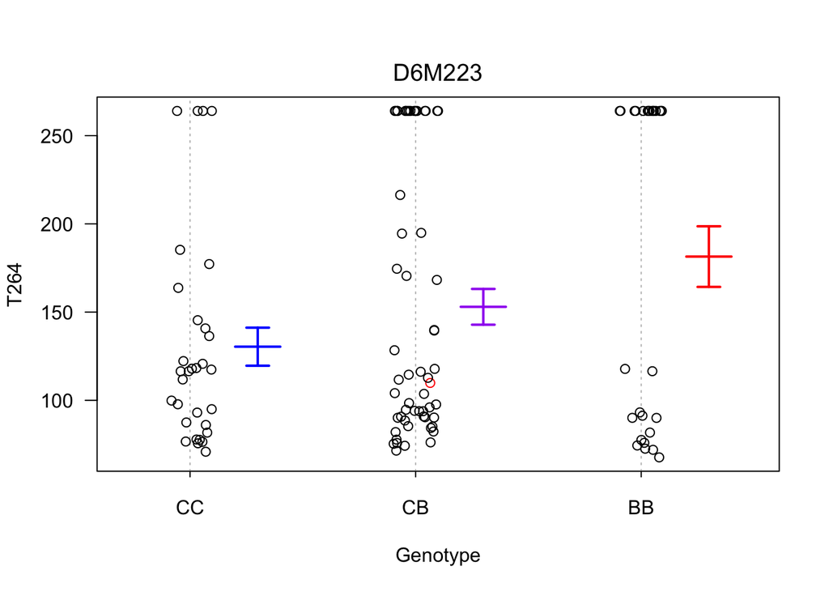

```r
plotPXG(listeria,"D6M223") # plot one marker as an example
```

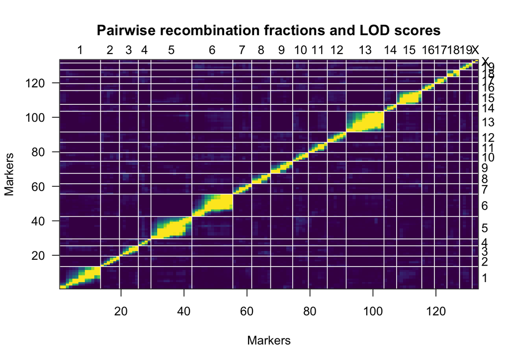

```r
plotRF(listeria) #estimate and plot the pairwise recombinant fraction, r
```

```r
# single marker analysis
## "mr" stands for "marker regression"
## scanone = 一次只scan一個
out.mr = scanone(listeria, method="mr")
# assume only one marker on each chromosome，且只在每個chr上選最顯著的marker
summary(out.mr)  # all markers
```

```
##         chr  pos    lod
## D1M355    1 81.4 2.0995
## D2M148    2 90.9 1.0501
## D3M147    3 63.2 1.7222
## D4M251    4 68.1 1.1744
## D5M357    5 25.5 6.3736
## D6M201    6 59.0 3.5205
## D7M105    7 60.1 0.5714
## D8M94     8  0.0 0.6937
## D9M247    9  0.0 0.9989
## D10M294  10 24.7 0.7597
## D11M333  11 64.3 0.2470
## D12M150  12 54.5 1.3180
## D13M147  13 26.2 5.8199
## D14M266  14 45.6 0.0725
## D15M68   15 23.9 3.0665
## D16M4    16 16.8 0.9920
## D17M88   17 17.3 0.4281
## D18M94   18  0.0 1.2303
## D19M117  19 16.4 0.4367
## DXM186    X  0.0 0.6784
```

```r
summary(out.mr, threshold=3) # markers which have LOD score > 3
```

```
##         chr  pos  lod
## D5M357    5 25.5 6.37
## D6M201    6 59.0 3.52
## D13M147  13 26.2 5.82
## D15M68   15 23.9 3.07
```

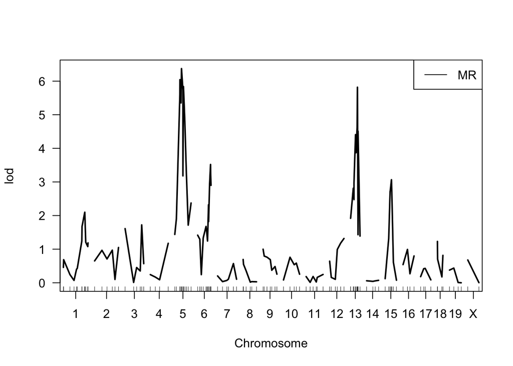

```r
plot(out.mr, col=1)
legend("topright",c("MR"), col=1, lty=1)
```

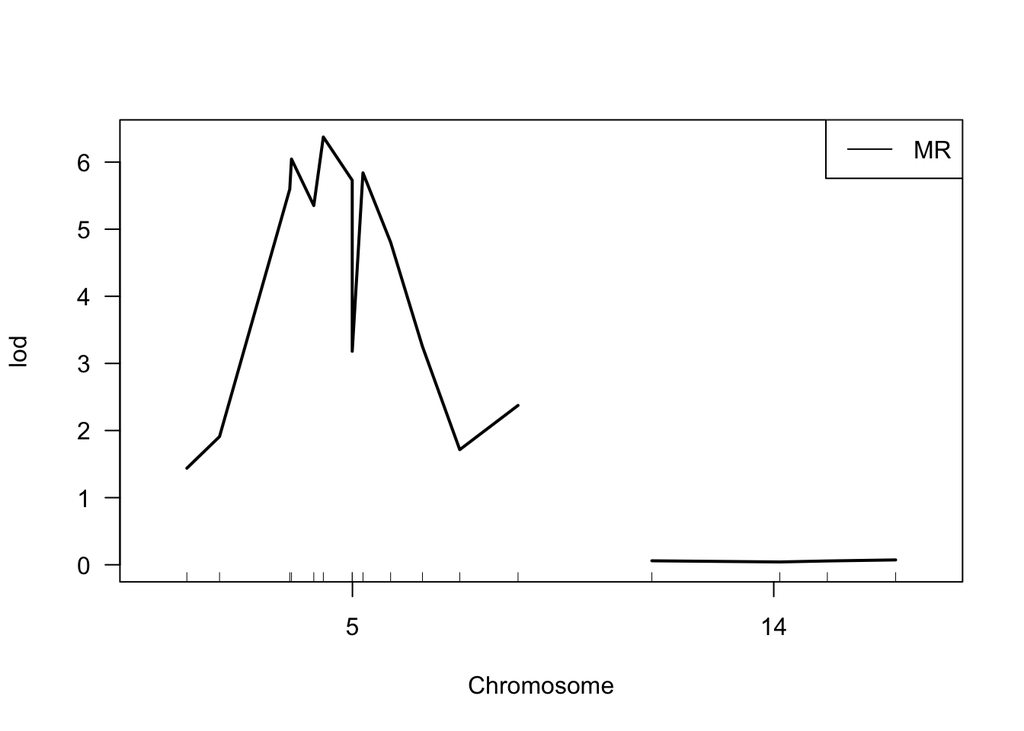

```r
# 人為選出大致上看起來最高及最平緩的區間畫圖
plot(out.mr, chr=c(5,14))
legend("topright",c("MR"), col=1, lty=1)
```

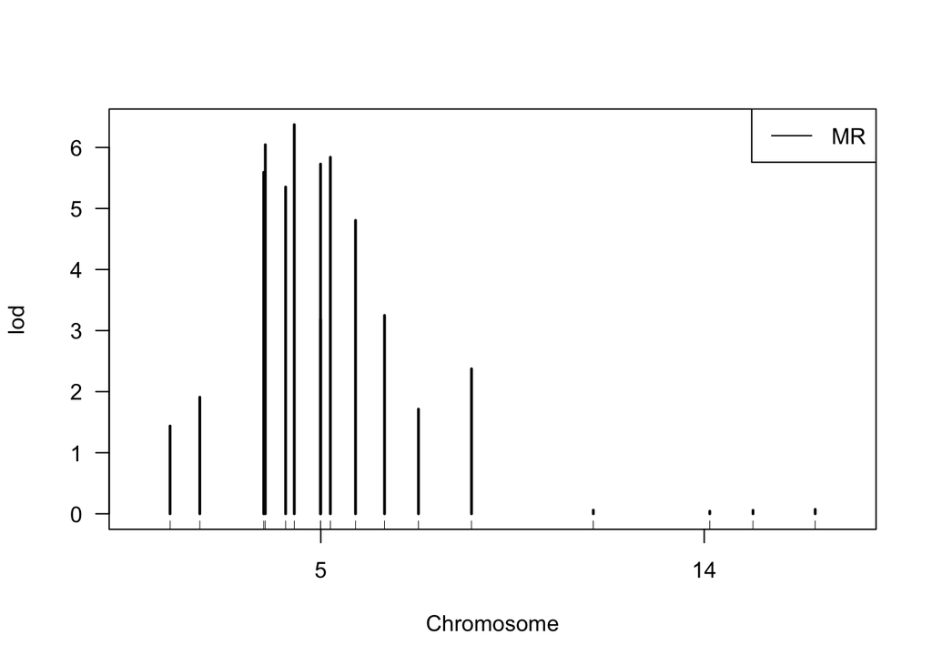

```r
plot(out.mr, chr=c(5,14), type="h")
legend("topright",c("MR"), col=1, lty=1)
```

#### In (b) and (c), we need:

```r
# interval mapping: IM (Lander; EM) or RIM (Harley-Knott; H-K)
# step: distance (in cM) between positions at which the genotype probabilities are calculated
listeria = calc.genoprob(listeria, step=1)  # 1 centimorgan , chromosome interval unit, grid search
```

2. Perform the interval mapping (Lander and Botstein, 1989), plot the results, and summarize the significant marker associated with the trait having permutation p-values < 0.05.

```r
# IM (Lander; EM)
listeria = calc.genoprob(listeria, step=1)  # 1 centimorgan , chromosome interval unit, grid search
out.em = scanone(listeria, method="em")
head(out.em) # show step = 1 (start from the 1st marker)
```

```
##         chr       pos       lod
## D10M44    1 0.0000000 0.5176036
## D1M3      1 0.9967536 0.7890489
## c1.loc1   1 1.0000000 0.7890850
## c1.loc2   1 2.0000000 0.8006054
## c1.loc3   1 3.0000000 0.8128694
## c1.loc4   1 4.0000000 0.8257975
```

```r
out.em[1:30,] #我們設定的檢查區間為1 centimorgan，若檢查區間無marker，則每次檢查區間皆為1，若檢查區間出現marker則會出現區間不為1的情況，如0-1之間的D1M3、24-25之間的D1M75。
```

```
##          chr        pos       lod
## D10M44     1  0.0000000 0.5176036
## D1M3       1  0.9967536 0.7890489
## c1.loc1    1  1.0000000 0.7890850
## c1.loc2    1  2.0000000 0.8006054
## c1.loc3    1  3.0000000 0.8128694
## c1.loc4    1  4.0000000 0.8257975
## c1.loc5    1  5.0000000 0.8392365
## c1.loc6    1  6.0000000 0.8529268
## c1.loc7    1  7.0000000 0.8664614
## c1.loc8    1  8.0000000 0.8792338
## c1.loc9    1  9.0000000 0.8903843
## c1.loc10   1 10.0000000 0.8987518
## c1.loc11   1 11.0000000 0.9028589
## c1.loc12   1 12.0000000 0.9009639
## c1.loc13   1 13.0000000 0.8912284
## c1.loc14   1 14.0000000 0.8720146
## c1.loc15   1 15.0000000 0.8422866
## c1.loc16   1 16.0000000 0.8019942
## c1.loc17   1 17.0000000 0.7522869
## c1.loc18   1 18.0000000 0.6954012
## c1.loc19   1 19.0000000 0.6342356
## c1.loc20   1 20.0000000 0.5717689
## c1.loc21   1 21.0000000 0.5105668
## c1.loc22   1 22.0000000 0.4525256
## c1.loc23   1 23.0000000 0.3988415
## c1.loc24   1 24.0000000 0.3501187
## D1M75      1 24.8477329 0.3128326
## c1.loc25   1 25.0000000 0.3110778
## c1.loc26   1 26.0000000 0.2986533
## c1.loc27   1 27.0000000 0.2846228
```

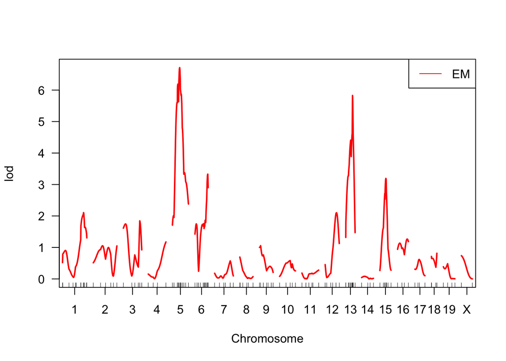

```r
plot(out.em, col=2)
legend("topright",c("EM"), col=2, lty=1)
```

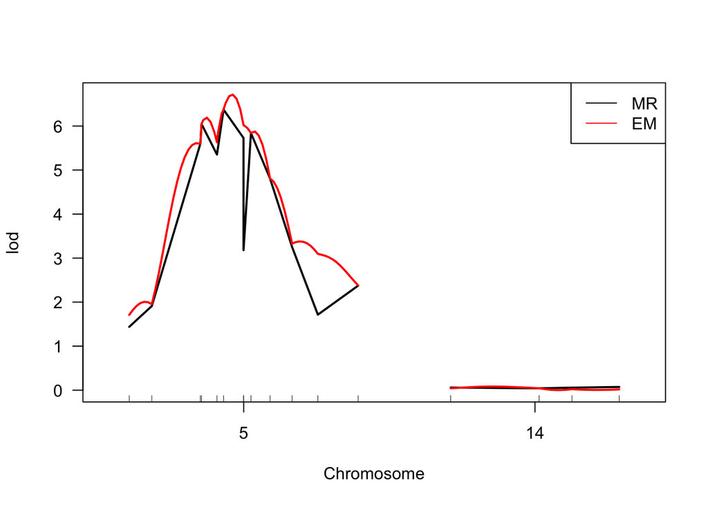

```r
plot(out.mr,out.em, chr=c(5,14),col=1:2)
legend("topright",c("MR","EM"), col=1:2, lty=1)
```

```r
# permutation test for IM
operm = scanone(listeria, method="em", n.perm=1000, verbose=FALSE) # verbose=FALSE: suppress output # n.perm = permutation
operm.f = data.frame(operm)
summary.em = summary(out.em, perms=operm, alpha=0.05, pvalues=TRUE)
summary.em
```

```
##     There were no LOD peaks above the threshold.
```

```r
# 由於沒有任何 marker 在 permutation 的結果中 p-values < 0.05，所以我重新設定一次，將 alpha 設為 0.1，找出以下兩個 marker。
summary.em.1 = summary(out.em, perms=operm, alpha=0.1, pvalues=TRUE)
summary.em.1
```

```
##          chr  pos  lod  pval
## c5.loc28   5 28.0 6.71 0.092
## D13M147   13 26.2 5.83 0.097
```

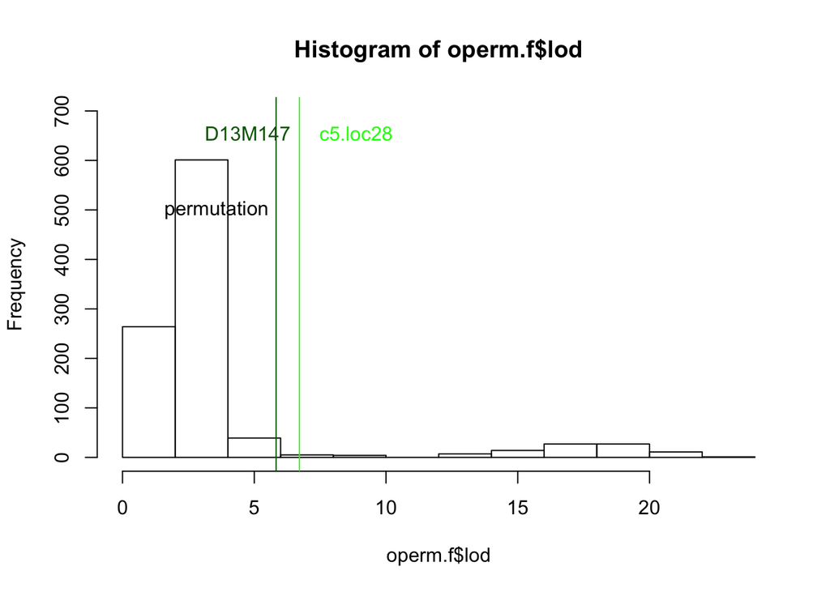

```r
# Plot those significant markers associated with the trait having permutation p-values < 0.1 (沒有任何 marker 在 permutation 的結果中 p-values < 0.05)
hist(operm.f$lod,ylim=c(0,700))
text(x=6, y=500,"permutation" , pos=2)
abline(v=summary.em.1$lod,col=c("green","darkgreen"))
text(x= summary.em.1$lod[1]+4, y=650, rownames(summary.em.1)[1], pos=2,col="green")
text(x= summary.em.1$lod[2]+1, y=650, rownames(summary.em.1)[2], pos=2,col="darkgreen")
```

3. Perform the regression interval mapping (Harley and Knott, 1992), plot the results, and summarize the significant marker associated with the trait having permutation p-values < 0.05.

```r
# RIM (Harley-Knott; H-K)
listeria = calc.genoprob(listeria, step=1)  # 1 centimorgan , chromosome interval unit, grid search
out.hk = scanone(listeria, method="hk") # method預設值＝ＥＭ
```

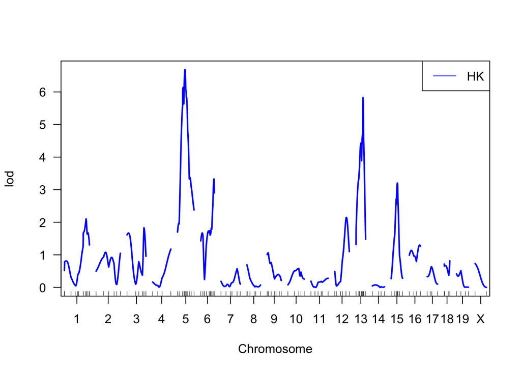

```r
plot(out.hk, col=4)
legend("topright",c("HK"), col=4, lty=1)
```

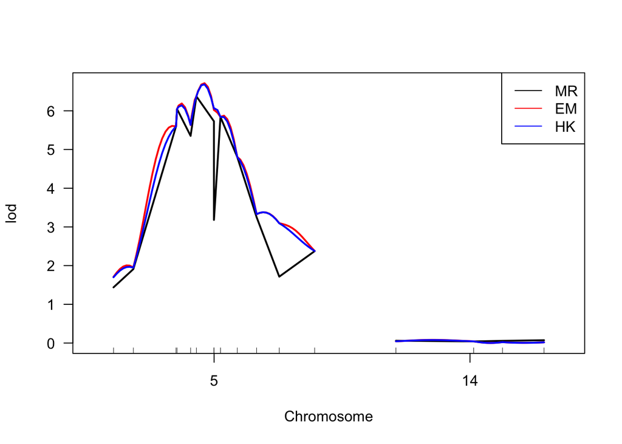

```r
plot(out.mr,out.em,out.hk, chr=c(5,14),col=c(1,2,4))
legend("topright",c("MR","EM","HK"), col=c(1,2,4), lty=1)
```

```r
# permutation test for HK
operhk = scanone(listeria, method="hk", n.perm=1000, verbose=FALSE) # verbose=FALSE: suppress output
operhk.f = data.frame(operhk)
summary.hk = summary(out.hk, perms=operhk, alpha=0.05, pvalues=TRUE)
summary.hk
```

```
##          chr  pos  lod  pval
## c5.loc28   5 28.0 6.68 0.000
## D13M147   13 26.2 5.83 0.001
```

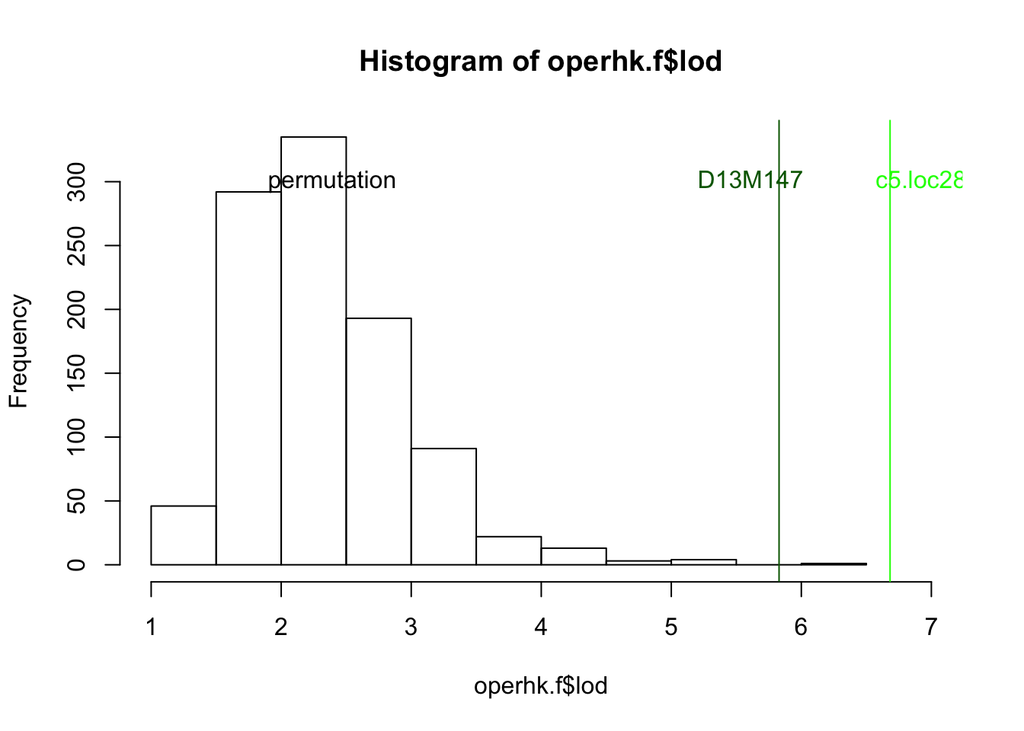

```r
# Plot those significant markers associated with the trait having permutation p-values < 0.05
hist(operhk.f$lod,xlim=c(1,7))
text(x=3, y=300,"permutation" , pos=2)
abline(v=summary.hk$lod,col=c("green","darkgreen"))
text(x= summary.hk$lod[1]+0.7, y=300, rownames(summary.hk)[1], pos=2, col="green")
text(x= summary.hk$lod[2]+0.3, y=300, rownames(summary.hk)[2], pos=2, col="darkgreen")
```

4. Compare the result of the above three methods for QTL mapping and draw an appropriate conclusion accordingly.

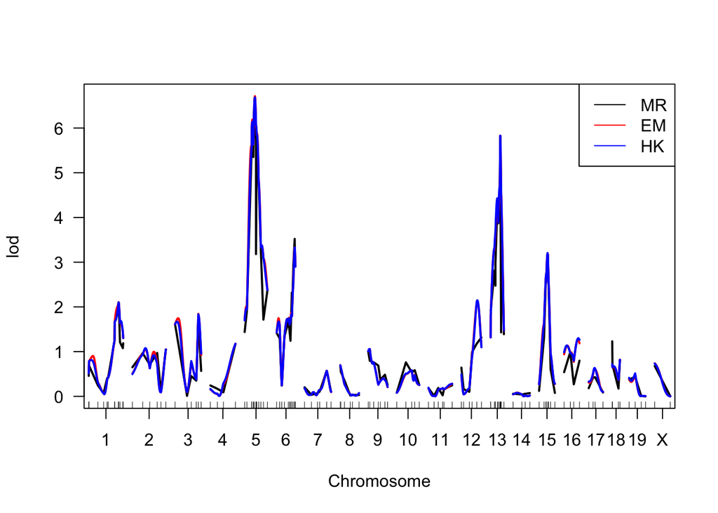

```r
plot(out.mr,out.em,out.hk, col=c(1,2,4))
legend("topright",c("MR","EM","HK"), col=c(1,2,4), lty=1)
```